[← Back to All Parables](https://www.kameronyork.com/parables/)

# The Two Debtors

by Kameron York

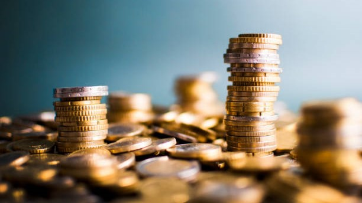

#### Reference:

[Luke 7:41-43](https://www.churchofjesuschrist.org/study/scriptures/nt/luke/7?lang=eng&id=41-43#p41)

#### Insights here:

**Points:**  
In this parable, unlike most, Jesus reveals the meaning. Jesus is invited to eat with a Pharisee named Simon. While having dinner, a “sinful” woman enters the house, cleans the savior’s feet sith her tears, and annoints his feet wirh oil from an alabaster box. Simon mutters, “Doesn’t He know this woman is a sinner?”, to which Jesus responds with this parable.  
The meaning of the parable follows the telling. After Simon rightly answers, Jesus says, “Simon, we’ve been having dinner for a while now and you haven’t washed my feet or annointed my them with oil.” Then he applies the meaning of the parable to this scenario, “Her sins, which are many, are forgiven; for she loved much…” ([Luke 7:47](https://www.churchofjesuschrist.org/study/scriptures/nt/luke/7?lang=eng&id=47#p47)). An interesting phrase! Because she has shown so much love, her sins are forgiven? Does this mean as long as we show love to others we can sin as much as we want? No, I believe the meaning is much deeper than the idea that, “loving others = forgiveness from sin.”  
I find it interesting that the phrasing shown im verse 47 is effectively the reverse of the story in the parable. In the parable the master forgives and the servant who owed most loves most. However, in the real world application of verse 47, the Savior mentions her great love and then says her sins are forgiven. But, let’s not allow this ordering to confuse us. Think of this real world example on a grand scale. This woman is washing and annointing the feet of the Messiah, the one who WILL forgive her sins. She is performing this act of love because this man is her Savior. Just like in the parable, Jesus has forgiven her of such a great amount. An amount that has moved her to compassionate acts of service.  
It’s interesting that there are a few givens in the parable.  
1. **Both people fell into debt**. The reasons for their circumstances are unknown, but they are both contracted for loans.  
2. **Neither person can pay their debt**. Again, their financial reasons for being unable to pay are unknown.  
3. **Both people ask for mercy, and are forgiven**. There are amounts of debt mentioned, but the creditor frankly forgives both of their debts regardless of amount.  
4. **Both people loved the creditor for forgiving them**. The parable is used to illustrate that one loved the creditor more, but the comparison shows that both loved.  
These givens are paralleled in our lives. Daily we fall into debt by sinning. We alone are unable to pay the debts for our sins and plead for forgiveness. Our creditor is merciful, willing to forgive anyone we asks for mercy. We then love the Lord more for allowing us - through His sacrifice - to be free.  
We’ve highlighted the similarities between the debtors, but what of their differences?  
1. **The amounts of debt**. One debtor only owes 50 pence while the other owes 500.  
2. **The amount of love**. As stated previously they both love the creditor, but the one who was forgiven of 500 pence loved more. The Savior went on to say, *“…but to whom little is forgiven, the same loveth little.”* Of this passage the New Testament institute manual says:  
*“Jesus Christ taught that people who choose not to seek the blessings of divine forgiveness for their sins are showing their lack of love for Him… we are warned that deliberate sin mocks the Savior’s Atonement. We should show our love for the Savior by striving to keep His commandments and sincerely repenting of our sins.”*  
Jesus saying that people we repent little love little makes sense. Our repentance, as was stated in the institute manual, is derived from our love for the Savior. And, just as both people in the parable were in debt, we are all debtors to sin. Therefore, if we all require repentance, then those who repent are showing their love and are forgiven, while those who don’t repent lack the love necessary to obtain forgiveness - solely because they don’t ask for it. Everyone is worthy of the love and forgiveness of Christ, but those without love for Him seem to disqualify themselves because of it.

[output not shown]